```r
# Necessary libraries
library(scales)
library(MASS)
library(tsne)
library(rpart)
library(Rtsne)
library(dplyr)
library(knitr)
library(stats)
library(caret)
library(gbm)
library(pROC)
library(ROCR)
library(partykit)
library(flexclust)
library(FactoMineR)
library(factoextra)
```

```r
library(rpart.plot)
library(randomForest)
# loading data
HMEQ <- read.csv("C:/Users/chhot/Downloads/GYPR/HMEQ_Scrubbed.csv")
```

```r
# first 6 rows
head(HMEQ)
```

```
##   TARGET_BAD_FLAG TARGET_LOSS_AMT LOAN IMP_MORTDUE M_MORTDUE IMP_VALUE M_VALUE
## 1               1             641 1100       25860         0     39025       0
## 2               1            1109 1300       70053         0     68400       0
## 3               1             767 1500       13500         0     16700       0
## 4               1            1425 1500       65000         1     89000       1
## 5               0               0 1700       97800         0    112000       0
## 6               1             335 1700       30548         0     40320       0
##   IMP_YOJ M_YOJ IMP_DEROG M_DEROG IMP_DELINQ M_DELINQ IMP_CLAGE M_CLAGE
## 1    10.5     0         0       0          0        0  94.36667       0
## 2     7.0     0         0       0          2        0 121.83333       0
## 3     4.0     0         0       0          0        0 149.46667       0
## 4     7.0     1         1       1          1        1 174.00000       1
## 5     3.0     0         0       0          0        0  93.33333       0
## 6     9.0     0         0       0          0        0 101.46600       0
##   IMP_NINQ M_NINQ IMP_CLNO M_CLNO IMP_DEBTINC M_DEBTINC FLAG.Job.Mgr
```

[output cut: 20 more lines]

# Step 1: Use the code from Week 7 as a Starting Point

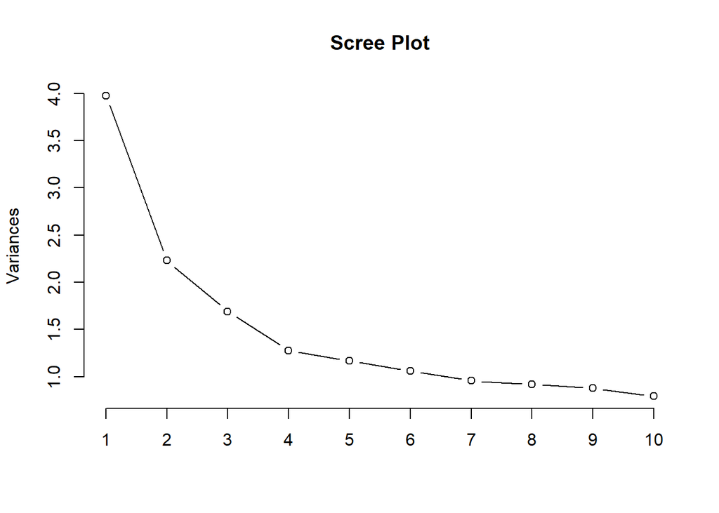

```
##                      PC1          PC2          PC3         PC4
## LOAN         0.073067236 -0.274860870  0.143828134 -0.03735318
## IMP_MORTDUE  0.070238024 -0.551961385  0.083562463  0.15415579
## M_MORTDUE   -0.199279438  0.136818534  0.165726813 -0.11200427
## IMP_VALUE    0.100776305 -0.557531636  0.121668607  0.10174623
## M_VALUE     -0.065279398 -0.001501880 -0.250774128 -0.24304929
## IMP_YOJ      0.061481766 -0.008289364  0.086843742 -0.57113108
## M_YOJ       -0.229428489  0.028566247  0.185723033 -0.02759637
## IMP_DEROG   -0.182983829 -0.057248985 -0.381162772 -0.04525554
## M_DEROG     -0.387559044 -0.142902728 -0.070309361 -0.02494576
## IMP_DELINQ  -0.112761752 -0.091609955 -0.426665315 -0.32649436
## M_DELINQ    -0.425194031 -0.096125607  0.002506417  0.04755769
## IMP_CLAGE    0.024823798 -0.213452580  0.205193953 -0.53165684
## M_CLAGE     -0.379468166 -0.026242714  0.127538480  0.08140126
## IMP_NINQ    -0.007877375 -0.066892874 -0.356290497  0.25385379
## M_NINQ      -0.420640255 -0.082041986  0.054683891  0.01364507
## IMP_CLNO     0.059635407 -0.388276826 -0.182755452 -0.17783046
## M_CLNO      -0.414255005 -0.070343216  0.092419203  0.04467791
## IMP_DEBTINC  0.068600101 -0.178987466 -0.237730067  0.24059098
## M_DEBTINC   -0.022547229  0.053022070 -0.453983762 -0.09471379
```

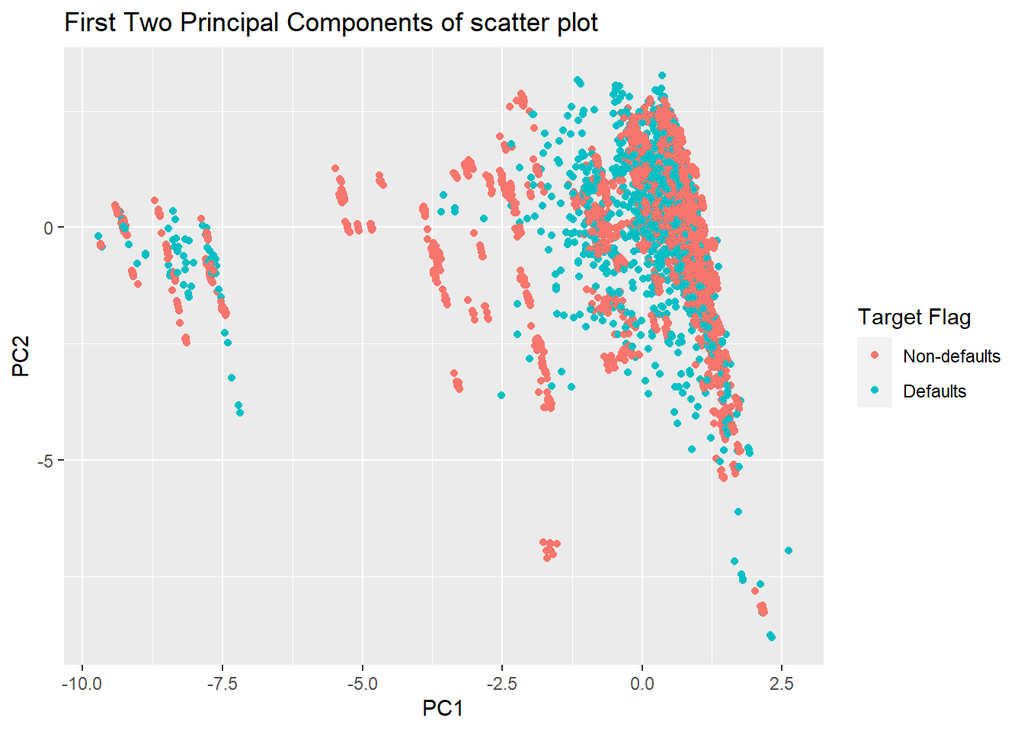

```r
suppressWarnings({
# we will use some column names
selected_columns <- HMEQ[, c("LOAN", "IMP_MORTDUE", "M_MORTDUE", "IMP_VALUE", "M_VALUE", "IMP_YOJ", "M_YOJ", "IMP_DEROG", "M_DEROG", "IMP_DELINQ", "M_DELINQ", "IMP_CLAGE", "M_CLAGE", "IMP_NINQ", "M_NINQ", "IMP_CLNO", "M_CLNO", "IMP_DEBTINC", "M_DEBTINC")]

# Standardize
scaled_HMEQ <- scale(selected_columns)

# Perform PCA with scaled data
pca_result <- prcomp(scaled_HMEQ)

# Scree Plot with lines
screeplot(pca_result, type = "lines", main = "Scree Plot")

# the number of principal components to use based on the Scree Plot
# first 4 components
num_components_to_use <- 4

# weights of the Principal Components
print(pca_result$rotation[, 1:num_components_to_use])

# Create a data frame with PC scores and Target Flag
pca_HMEQ <- data.frame(
  PC1 = pca_result$x[, 1],
  PC2 = pca_result$x[, 2],
  Target_Flag = HMEQ$TARGET_BAD_FLAG
)

# Scatter Plot of the first two Principal Components
library(ggplot2)
ggplot(pca_HMEQ, aes(x = PC1, y = PC2, color = factor(Target_Flag))) +
  geom_point() +
  labs(title = "First Two Principal Components of scatter plot") +
  scale_color_discrete(name = "Target Flag", labels = c("Non-defaults", "Defaults"))
})
```

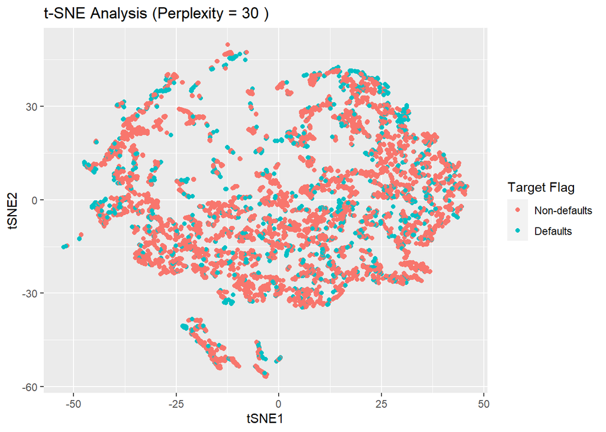

```r
suppressWarnings({

# Select the columns you want to include in t-SNE
selected_columns <- HMEQ[, c("LOAN", "IMP_MORTDUE", "M_MORTDUE", "IMP_VALUE", "M_VALUE", "IMP_YOJ", "M_YOJ", "IMP_DEROG", "M_DEROG", "IMP_DELINQ", "M_DELINQ", "IMP_CLAGE", "M_CLAGE", "IMP_NINQ", "M_NINQ", "IMP_CLNO", "M_CLNO", "IMP_DEBTINC", "M_DEBTINC")]

# Perform t-SNE analysis with your preferred perplexity value
perplexity_value <- 30
tsne_result <- Rtsne(selected_columns, perplexity = perplexity_value, dims = 2)

# Create a data frame with t-SNE results and Target Flag
tsne_HMEQ <- data.frame(
  tSNE1 = tsne_result$Y[, 1],
  tSNE2 = tsne_result$Y[, 2],
  Target_Flag = HMEQ$TARGET_BAD_FLAG
)

# Scatter Plot of t-SNE results
ggplot(tsne_HMEQ, aes(x = tSNE1, y = tSNE2, color = factor(Target_Flag))) +
  geom_point() +
  labs(title = paste("t-SNE Analysis (Perplexity =", perplexity_value, ")")) +
  scale_color_discrete(name = "Target Flag", labels = c("Non-defaults", "Defaults"))

})
```

# Step 2: PCA Analysis

# • Use only the input variables. Do not use either of the target variables.

# • Use only the continuous variables. Do not use any of the flag variables.

# • Select at least 4 of the continuous variables. It would be preferable if there were a theme to the variables selected.

# • Do a Principal Component Analysis (PCA) on the continuous variables.

# • Display the Scree Plot of the PCA analysis.

# • Using the Scree Plot, determine how many Principal Components you wish to use. Note, you must use at least two. You may decide to use more. Justify your decision. Note that there is no wrong answer. You will be graded on your reasoning, not your decision.

# • Print the weights of the Principal Components. Use the weights to tell a story on what the Principal Components represent.

# • Perform a scatter plot using the first two Principal Components. Do not color the dots. Leave them black.

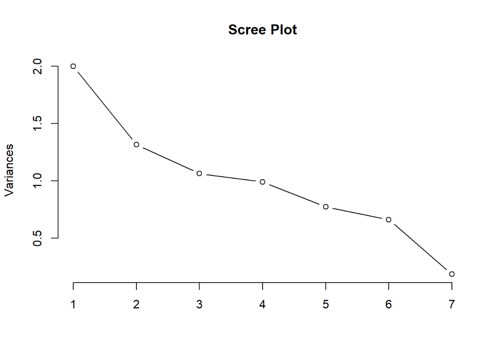

```r
# Step 2: PCA analysis

# Select the continuous variables you want to include in PCA
selected_continuous_variables <- HMEQ[, c("LOAN", "IMP_MORTDUE", "M_MORTDUE", "IMP_VALUE", "M_VALUE", "IMP_YOJ", "M_YOJ")]

# Standardize continuous variables (center and scale)
scaled_continuous_vars <- scale(selected_continuous_variables)

# PCA
pca_result <- prcomp(scaled_continuous_vars)

# Scree Plot
screeplot(pca_result, type = "lines", main = "Scree Plot")
```

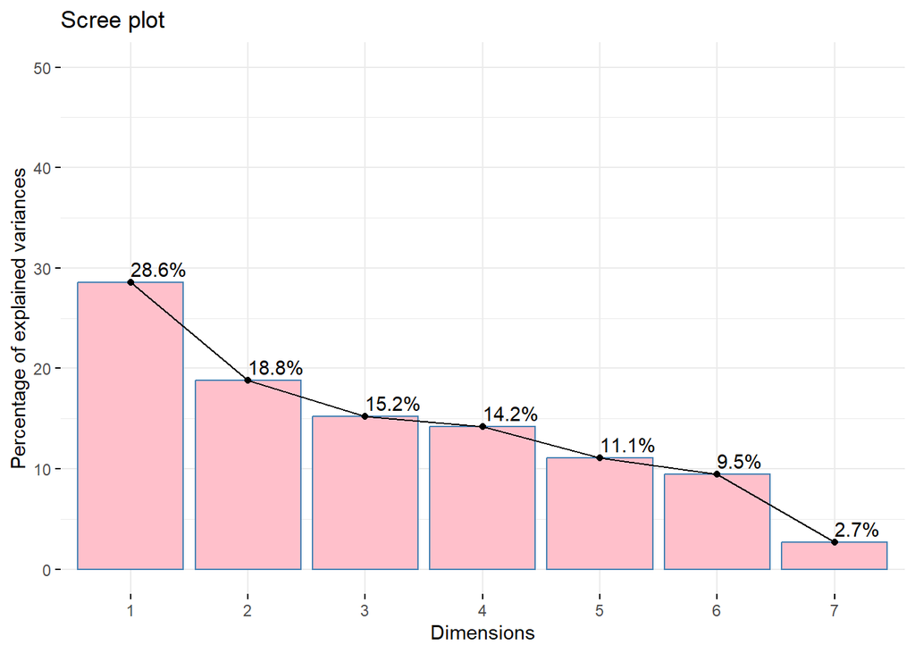

```r
fviz_eig(pca_result, barfill = 'pink', ggplot = theme_bw() , addlabels = TRUE, ylim = c(0, 50))
```

```r
# There is no one-size-fits-all answer; it depends on your specific analysis goals.
# Based on the Scree Plot, determine the number of Principal Components to use.
# You can visually inspect the plot to decide how many components to retain. # Justify your decision based on the variance explained by the components.
# In your explanation, consider how much variance you want to retain and the trade-off with dimensionality reduction.
# Assume for the purposes of this example that you choose to keep the first two elements.

# Print the weights of the Principal Components
# These weights indicate the contribution of each original variable to each Principal Component
print(pca_result$rotation[, 1:2])
```

```
##                     PC1         PC2
## LOAN         0.34647456 -0.23964883
## IMP_MORTDUE  0.61534772 -0.16886004
## M_MORTDUE   -0.21369320 -0.63652240
## IMP_VALUE    0.65490511 -0.09602874
## M_VALUE     -0.03838155 -0.16237564
## IMP_YOJ      0.01443236  0.18436066
## M_YOJ       -0.15828971 -0.66281049
```

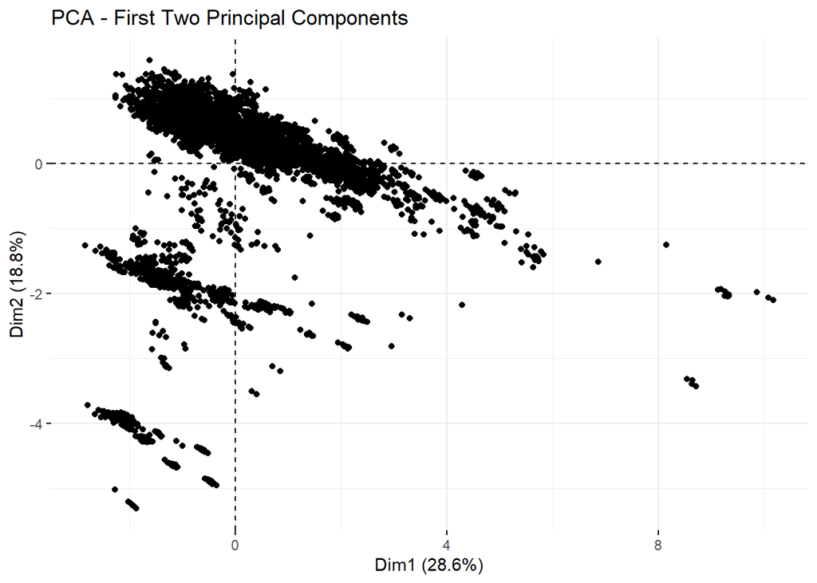

```r
# Perform a scatter plot using the first two Principal Components (black dots)
# Create a data frame with PC scores
pca_HMEQ <- data.frame(
  PC1 = pca_result$x[, 1],
  PC2 = pca_result$x[, 2] )

# Scatter plot using for the first two Principal Components
fviz_pca_ind(pca_result, geom.ind = "point", col.ind = 'black',
             title = "PCA - First Two Principal Components")
```

# Step 3: Cluster Analysis - Find the Number of Clusters

# • Use the principal components from Step 2 for this step.

# • Using the methods presented in the lectures, complete a KMeans cluster analysis for N=1 to at least N=10. Feel free to take the number higher.

# • Print a scree plot of the clusters and determine how many clusters would be optimum. Justify your decision.

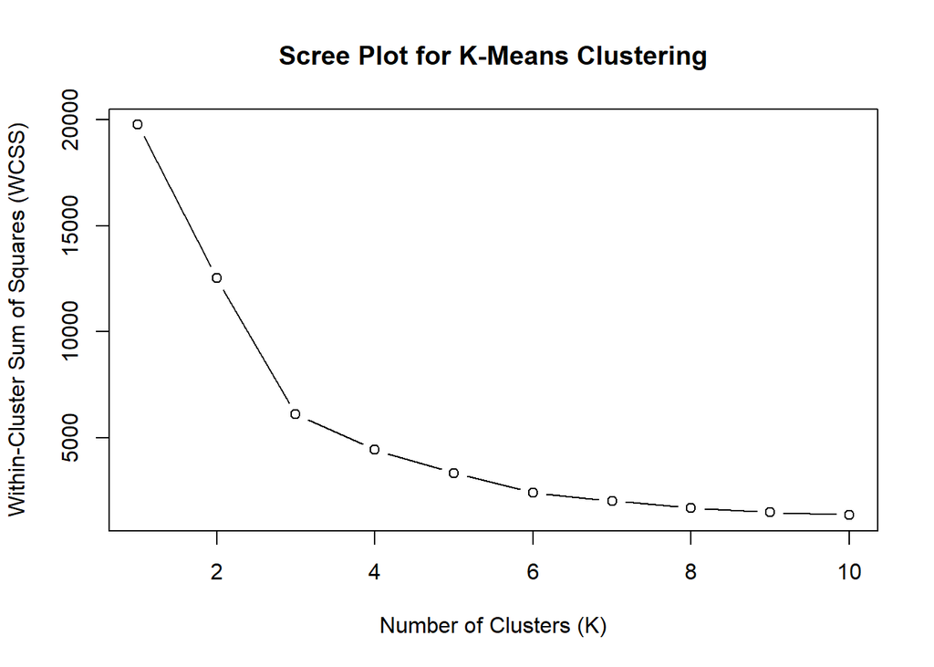

```r
# principal components obtained in Step 2
principal_components <- pca_result$x[, 1:2]

# find of variables to store within-cluster sum of squares (WCSS) for different cluster counts
wcss <- vector('numeric', length = 10)  # You can change the range if needed

# K-Means clustering for N=1 to N=10
for (i in 1:10) {
  kmeans_model <- kmeans(principal_components, centers = i, nstart = 10)  # You can adjust nstart as needed

  # Store the WCSS for each cluster counting
  wcss[i] <- kmeans_model$tot.withinss
}

# Create a Scree Plot to visualize the within-cluster sum of squares (WCSS) for different cluster counts
plot(1:10, wcss, type = "b",
     xlab = "Number of Clusters (K)",
     ylab = "Within-Cluster Sum of Squares (WCSS)",
     main = "Scree Plot for K-Means Clustering")
```

```r
# Print the number of clusters you determined as optimal
optimal_cluster_count <- 3
cat("Optimal Number of Clusters:", optimal_cluster_count, "\n")
```

```
## Optimal Number of Clusters: 3
```

# Step 4: Cluster Analysis

# • Using the number of clusters from step 3, perform a cluster analysis using the principle components from Step 2.

# • Print the number of records in each cluster.

# • Print the cluster center points for each cluster

# • Convert the KMeans clusters into “flexclust” clusters

# • Print the barplot of the cluster. Describe the clusters from the barplot.

# • Score the training data using the flexclust clusters. In other words, determine which cluster they are in.

# • Perform a scatter plot using the first two Principal Components. Color the plot by the cluster membership.